# Reduced

```python
import pandas as pd
import numpy as np
```

```python
!ls -l *.csv
```

```
-rw-rw-r-- 1 prateek prateek 120731 Oct 18 19:10 discrete.csv
-rw-rw-r-- 1 prateek prateek 120731 Nov 22 12:39 final.csv
-rw-rw-r-- 1 prateek prateek 115750 Oct 18 10:39 merge.csv
-rw-rw-r-- 1 prateek prateek   7264 Oct 15 12:47 regression.csv
-rwxrwxrwx 1 prateek prateek 110313 Sep  1 19:50 student.csv
-rw-rw-r-- 1 prateek prateek  14210 Nov 22 13:09 sub.csv
-rw-rw-r-- 1 prateek prateek  78300 Nov 22 12:39 x.csv
-rw-rw-r-- 1 prateek prateek  26100 Nov 22 12:39 y.csv
```

```python
df = pd.read_csv('student.csv')
df.shape
```

```
(1044, 33)
```

```python
df.describe()
```

|  | age | Medu | Fedu | traveltime | studytime | failures | famrel | freetime | goout | Dalc | Walc | health | absences | G1 | G2 | G3 |
| --- | --- | --- | --- | --- | --- | --- | --- | --- | --- | --- | --- | --- | --- | --- | --- | --- |
| count | 1044.000000 | 1044.000000 | 1044.000000 | 1044.000000 | 1044.000000 | 1044.000000 | 1044.000000 | 1044.000000 | 1044.000000 | 1044.000000 | 1044.000000 | 1044.000000 | 1044.000000 | 1044.000000 | 1044.000000 | 1044.000000 |
| mean | 16.726054 | 2.603448 | 2.387931 | 1.522989 | 1.970307 | 0.264368 | 3.935824 | 3.201149 | 3.156130 | 1.494253 | 2.284483 | 3.543103 | 4.434866 | 11.213602 | 11.246169 | 11.341954 |
| std | 1.239975 | 1.124907 | 1.099938 | 0.731727 | 0.834353 | 0.656142 | 0.933401 | 1.031507 | 1.152575 | 0.911714 | 1.285105 | 1.424703 | 6.210017 | 2.983394 | 3.285071 | 3.864796 |
| min | 15.000000 | 0.000000 | 0.000000 | 1.000000 | 1.000000 | 0.000000 | 1.000000 | 1.000000 | 1.000000 | 1.000000 | 1.000000 | 1.000000 | 0.000000 | 0.000000 | 0.000000 | 0.000000 |
| 25% | 16.000000 | 2.000000 | 1.000000 | 1.000000 | 1.000000 | 0.000000 | 4.000000 | 3.000000 | 2.000000 | 1.000000 | 1.000000 | 3.000000 | 0.000000 | 9.000000 | 9.000000 | 10.000000 |
| 50% | 17.000000 | 3.000000 | 2.000000 | 1.000000 | 2.000000 | 0.000000 | 4.000000 | 3.000000 | 3.000000 | 1.000000 | 2.000000 | 4.000000 | 2.000000 | 11.000000 | 11.000000 | 11.000000 |
| 75% | 18.000000 | 4.000000 | 3.000000 | 2.000000 | 2.000000 | 0.000000 | 5.000000 | 4.000000 | 4.000000 | 2.000000 | 3.000000 | 5.000000 | 6.000000 | 13.000000 | 13.000000 | 14.000000 |
| max | 22.000000 | 4.000000 | 4.000000 | 4.000000 | 4.000000 | 3.000000 | 5.000000 | 5.000000 | 5.000000 | 5.000000 | 5.000000 | 5.000000 | 75.000000 | 19.000000 | 19.000000 | 20.000000 |

```python
df.head()
```

|  | school | sex | age | address | famsize | Pstatus | Medu | Fedu | Mjob | Fjob | ... | famrel | freetime | goout | Dalc | Walc | health | absences | G1 | G2 | G3 |
| --- | --- | --- | --- | --- | --- | --- | --- | --- | --- | --- | --- | --- | --- | --- | --- | --- | --- | --- | --- | --- | --- |
| 0 | GP | F | 18 | U | GT3 | A | 4 | 4 | at_home | teacher | ... | 4 | 3 | 4 | 1 | 1 | 3 | 6 | 5 | 6 | 6 |
| 1 | GP | F | 17 | U | GT3 | T | 1 | 1 | at_home | other | ... | 5 | 3 | 3 | 1 | 1 | 3 | 4 | 5 | 5 | 6 |
| 2 | GP | F | 15 | U | LE3 | T | 1 | 1 | at_home | other | ... | 4 | 3 | 2 | 2 | 3 | 3 | 10 | 7 | 8 | 10 |
| 3 | GP | F | 15 | U | GT3 | T | 4 | 2 | health | services | ... | 3 | 2 | 2 | 1 | 1 | 5 | 2 | 15 | 14 | 15 |
| 4 | GP | F | 16 | U | GT3 | T | 3 | 3 | other | other | ... | 4 | 3 | 2 | 1 | 2 | 5 | 4 | 6 | 10 | 10 |

5 rows × 33 columns

```python
from matplotlib import pyplot as plt
%matplotlib inline
```

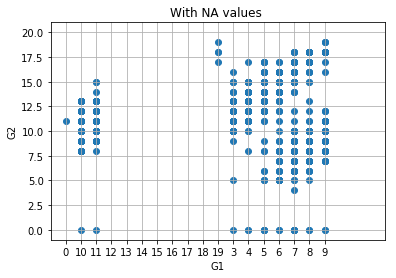

```python
plt.title('With NA values ')
plt.scatter(df[['G1']],df['G2'])
plt.xlabel('G1')
plt.ylabel('G2')
plt.xlim([-1,21])
plt.ylim([-1,21])
plt.grid()
```

### Dropping NA's:-

If we remove all the NAs(i.e. ZERO values):-

```python
data = df[df.G1!=0]
data =  data[data.G2!=0]
data.shape
```

```
(1023, 33)
```

```python
t1,t2 = df.shape,data.shape
print ("%s Records Lost"%(t1[0]-t2[0]))
```

```
21 Records Lost
```

- If we target **G1 and G2**, we will lead to **loss of 21 records** alone.
- G3 has approx 53 missing values

```python
data.describe()
```

|  | age | Medu | Fedu | traveltime | studytime | failures | famrel | freetime | goout | Dalc | Walc | health | absences | G1 | G2 | G3 |
| --- | --- | --- | --- | --- | --- | --- | --- | --- | --- | --- | --- | --- | --- | --- | --- | --- |
| count | 1023.000000 | 1023.000000 | 1023.000000 | 1023.000000 | 1023.000000 | 1023.000000 | 1023.000000 | 1023.000000 | 1023.000000 | 1023.000000 | 1023.000000 | 1023.000000 | 1023.000000 | 1023.000000 | 1023.000000 | 1023.000000 |
| mean | 16.719453 | 2.606061 | 2.390029 | 1.516129 | 1.975562 | 0.252199 | 3.932551 | 3.195503 | 3.149560 | 1.495601 | 2.289345 | 3.533724 | 4.521994 | 11.304985 | 11.466276 | 11.564027 |
| std | 1.236466 | 1.126206 | 1.098557 | 0.727893 | 0.836069 | 0.638715 | 0.931271 | 1.034105 | 1.146814 | 0.915046 | 1.285305 | 1.428185 | 6.242119 | 2.920145 | 2.913728 | 3.560431 |
| min | 15.000000 | 0.000000 | 0.000000 | 1.000000 | 1.000000 | 0.000000 | 1.000000 | 1.000000 | 1.000000 | 1.000000 | 1.000000 | 1.000000 | 0.000000 | 3.000000 | 4.000000 | 0.000000 |
| 25% | 16.000000 | 2.000000 | 1.000000 | 1.000000 | 1.000000 | 0.000000 | 4.000000 | 3.000000 | 2.000000 | 1.000000 | 1.000000 | 2.000000 | 0.000000 | 9.000000 | 9.000000 | 10.000000 |
| 50% | 17.000000 | 3.000000 | 2.000000 | 1.000000 | 2.000000 | 0.000000 | 4.000000 | 3.000000 | 3.000000 | 1.000000 | 2.000000 | 4.000000 | 2.000000 | 11.000000 | 11.000000 | 11.000000 |
| 75% | 18.000000 | 4.000000 | 3.000000 | 2.000000 | 2.000000 | 0.000000 | 5.000000 | 4.000000 | 4.000000 | 2.000000 | 3.000000 | 5.000000 | 6.000000 | 13.000000 | 13.000000 | 14.000000 |
| max | 22.000000 | 4.000000 | 4.000000 | 4.000000 | 4.000000 | 3.000000 | 5.000000 | 5.000000 | 5.000000 | 5.000000 | 5.000000 | 5.000000 | 75.000000 | 19.000000 | 19.000000 | 20.000000 |

```python
dd = df
temp = dd[['G1','G2']]
temp=temp.replace(0,np.NaN).fillna(dd.mean())
#temp
```

```python
dd['G1'],dd['G2']=temp['G1'],temp['G2']
```

```python
#dd.to_csv('check.csv')
```

We have replaced all the missing values of G1 & G2 with that of the Mean values of the columns.

```python
G3 = dd[dd.G3==0]
len(G3)
```

```
53
```

**We are yet having 53 missing values in G3**

## Making a Regression Model:-

This model will be used for the prediction of the **53 missing values**.

```python
m = dd[dd.G3!=0]
```

```python
# m.to_csv("filer.csv")
```

```python
x = np.meshgrid(m[['G3']])
x = x[0]
x.sort()
```

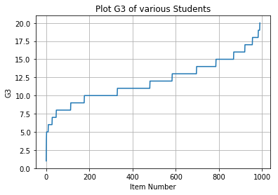

```python
plt.title('Plot G3 of various Students')
plt.plot(x)
plt.xlabel('Item Number')
plt.ylabel('G3')
plt.ylim([0,21])
plt.grid()
```

### Cross Validation

```python
from sklearn.model_selection import cross_val_score
data = m[['G1','G2','G3']].as_matrix()
X,Y = data[:,0:2],data[:,2]
```

## Linear Regression

```python
from sklearn.linear_model import LinearRegression
clf = LinearRegression()
print (np.average(cross_val_score(clf,X,Y,cv=5))*100)
```

```
88.744930335
```

### Predicting out of Sample Data:-

```python
out = dd[dd.G3==0]
```

```python
len(out)
```

```
53
```

```python
x_test = out[['G1','G2']]
#x_test
clf = LinearRegression().fit(X,Y)
g3 = clf.predict(x_test)
```

```python
#g3
type(g3)
```

```
numpy.ndarray
```

```python
out.loc[:,'G3'] = pd.Series(g3,index=out.index)
```

```python
# out.to_csv('regression.csv')
```

```python
final = m.append(out)
```

## Discretization of values:-

```python
dup = 0
for i in final.duplicated():
    if i is True:
        dup+=1

print ('No of duplicate '+str(dup)+' values')
```

```
No of duplicate 0 values
```

```python
marks1 = final['G1'].as_matrix()
marks2 = final['G2'].as_matrix()
marks3 = final['G3'].as_matrix()
bins = [i for i in range(1,21)]
```

```python
# marks1
m1 = np.array([])

for i in np.digitize(marks1,bins):
    m1=np.append(m1,i)

# marks2
m2 = np.array([])
for i in np.digitize(marks2,bins):
    m2=np.append(m2,i)

# marks3
m3 = np.array([])
for i in np.digitize(marks3,bins):
    m3=np.append(m3,i)

final.loc[:,'G1'] = pd.Series(m1,index=final.index)
final.loc[:,'G2'] = pd.Series(m2,index=final.index)
final.loc[:,'G3'] = pd.Series(m3,index=final.index)
#final
```

# CSV Cleaning:-

This is the CSV after

- **Regression model**
- filling G1 & G2 with **MEAN** Values
- Discretization

```python
final.to_csv('final.csv')
```

## Data Representaion

Below is the *Area Graph* of the G1, G2 & G3

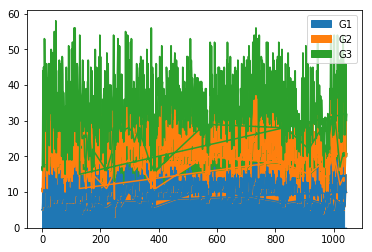

```python
final[['G1','G2','G3']].plot(kind='area')
```

Below is the *Scatter Graph* of the G1, G2 & G3 showing the values after cleaning

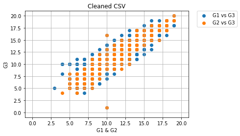

```python
plt.title('Cleaned CSV')
plt.scatter(final['G1'],final['G3'],label='G1 vs G3')
plt.scatter(final['G2'],final['G3'],label='G2 vs G3')
plt.xlabel('G1 & G2')
plt.ylabel('G3')
plt.xlim([-1,21])
plt.ylim([-1,21])
plt.grid()
plt.legend(bbox_to_anchor=(1.05, 1), loc=2, borderaxespad=0.)
```

## Data Preparation

```python
final.columns
```

```
Index(['school', 'sex', 'age', 'address', 'famsize', 'Pstatus', 'Medu', 'Fedu',
       'Mjob', 'Fjob', 'reason', 'guardian', 'traveltime', 'studytime',
       'failures', 'schoolsup', 'famsup', 'paid', 'activities', 'nursery',
       'higher', 'internet', 'romantic', 'famrel', 'freetime', 'goout', 'Dalc',
       'Walc', 'health', 'absences', 'G1', 'G2', 'G3'],
      dtype='object')
```

```python
df = final.as_matrix()
len(df)
```

```
1044
```

```python
df.flags.writeable = True



for i in range(0,len(df)):
    for j in range(15,23):
        if df[i,j] == 'yes':
            df[i,j] = 1
        else:
            df[i,j] = 0

    if df[i,3] == 'R':
        df[i,3] = 1
    else:
        df[i,3] = 0
```

```python
import numpy as np
x = [i for i in range(14,33)]
x = np.append(x,3)
x=np.sort(x)
x
```

```
array([ 3, 14, 15, 16, 17, 18, 19, 20, 21, 22, 23, 24, 25, 26, 27, 28, 29,
       30, 31, 32])
```

```python
X = np.array([])
for i in df[0:]:
    for j in x:
        X = np.append(X,float(i[j]))

print(len(X),len(x))
```

```
20880 20
```

```python
final.shape
```

```
(1044, 33)
```

```python
X = X.reshape((1044,20))
```

```python
X
```

```
array([[  0.,   0.,   1., ...,   5.,   6.,   6.],
       [  0.,   0.,   0., ...,   5.,   5.,   6.],
       [  0.,   3.,   1., ...,   7.,   8.,  10.],
       ...,
       [  1.,   0.,   0., ...,   7.,   7.,   7.],
       [  1.,   1.,   0., ...,   5.,   8.,   7.],
       [  1.,   1.,   0., ...,   7.,   7.,   7.]])
```

## Machine Learning

### Feature Extraction

```python
from sklearn.ensemble import ExtraTreesClassifier
model = ExtraTreesClassifier()
model.fit(X[:,0:19],X[:,19])
imp = model.feature_importances_
```

```python
header = ['address', 'failures', 'schoolsup', 'famsup', 'paid', 'activities',
       'nursery', 'higher', 'internet', 'romantic', 'famrel', 'freetime',
       'goout', 'Dalc', 'Walc', 'health', 'absences', 'G1', 'G2']

for i in range(0,19):
    print(i,header[i],imp[i]*100)
```

```
0 address 2.44398564191
1 failures 2.7958720054
2 schoolsup 1.59448496206
3 famsup 3.18005343746
4 paid 3.0156222406
5 activities 2.89344047929
6 nursery 2.81155017291
7 higher 1.13788777444
8 internet 2.38488655336
9 romantic 3.48125537518
10 famrel 5.69462357575
11 freetime 6.06582024977
12 goout 6.46889550395
13 Dalc 2.99839546948
14 Walc 5.05708306845
15 health 6.0906909963
16 absences 7.81686336679
17 G1 13.7705388337
18 G2 20.2980502932
```

Above us the Support Value for the features:-

- G2
- G1
- absent
- going out with friends
- health
- free time
- family relation
- weekly alcohal
- daily support

```python
total_imp=sum(imp)
area =[(i*360) for i in imp]
```

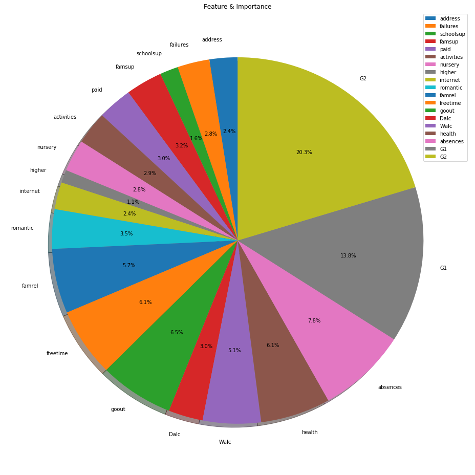

```python
plt.figure(figsize=(13,13))
plt.title('Feature & Importance')
plt.pie(area,labels=header,shadow=True, startangle=90,autopct='%1.1f%%')
plt.legend(header, loc="best")
plt.tight_layout()
```

```python
x,y = X[:,0:19],X[:,19]
features = [16,17,18]
```

```python
# Take all the feature in the dataset
X_ = np.array([])
for i in x:
    for j in features:
        X_ = np.append(X_,i[j])
X_ = np.reshape(X_,(1044,3))
```

```python
# Changing the labels to True/False for Pass/Fail correspondingly
Y_ = []
for i in range(0,len(y)):
    if(y[i]>=8):
        Y_.append(True)
    else:
        Y_.append(False)
```

```python
np.savetxt("x.csv", X_, delimiter=",")
np.savetxt("y.csv", Y_, delimiter=",")
```

```python
from sklearn.model_selection import train_test_split
from sklearn.metrics import accuracy_score
X_train, X_test, Y_train, Y_test = train_test_split(X_, Y_, test_size=0.20, random_state=42)
```

## Supervised Learning:-

- Decision Tree
- Random Forest
- Support Vector Machine
- K Nearest Neighbour
- Naive Bayes
- Logistic Regression

```python
result = []
import timeit
from sklearn.externals import joblib
```

### Decision Tree:-

```python
from sklearn.tree import DecisionTreeClassifier
start = timeit.default_timer()
clf = DecisionTreeClassifier().fit(X_train,Y_train)
prediction = clf.predict(X_test)
result.append(accuracy_score(prediction,Y_test))
print("Accuracy is %.2f"%accuracy_score(prediction,Y_test))
print("Time take "+str(timeit.default_timer()-start))
```

```
Accuracy is 0.94
Time take 0.0035031020006499602
```

## Random Forest:-

```python
from sklearn.ensemble import RandomForestClassifier
start = timeit.default_timer()
clf = RandomForestClassifier().fit(X_train,Y_train)
prediction = clf.predict(X_test)
result.append(accuracy_score(prediction,Y_test))
print("Accuracy is %.2f"%accuracy_score(prediction,Y_test))
print("Time take "+str(timeit.default_timer()-start))
```

```
Accuracy is 0.95
Time take 0.024361090000638796
```

## Support Vector Machine:-

```python
from sklearn.svm import SVC
start = timeit.default_timer()
clf = SVC().fit(X_train,Y_train)
prediction = clf.predict(X_test)
result.append(accuracy_score(prediction,Y_test))
print("Accuracy is %.2f"%accuracy_score(prediction,Y_test))
print("Time take "+str(timeit.default_timer()-start))
```

```
Accuracy is 0.94
Time take 0.03922220999993442
```

## K Nearest Neighbour:-

```python
from sklearn.neighbors import KNeighborsClassifier
start = timeit.default_timer()
clf = KNeighborsClassifier().fit(X_train,Y_train)
prediction = clf.predict(X_test)
result.append(accuracy_score(prediction,Y_test))
print("Accuracy is %.2f"%accuracy_score(prediction,Y_test))
print("Time take "+str(timeit.default_timer()-start))
```

```
Accuracy is 0.94
Time take 0.005927265000536863
```

## Naive Bayes:-

#### 1.GaussianNB

```python
from sklearn.naive_bayes import GaussianNB
start = timeit.default_timer()
clf = GaussianNB().fit(X_train,Y_train)
prediction = clf.predict(X_test)
result.append(accuracy_score(prediction,Y_test))
print("Accuracy is %.2f"%accuracy_score(prediction,Y_test))
print("Time take "+str(timeit.default_timer()-start))
```

```
Accuracy is 0.95
Time take 0.003624512999522267
```

#### 2.BernoulliNB

```python
from sklearn.naive_bayes import BernoulliNB
start = timeit.default_timer()
clf = BernoulliNB().fit(X_train,Y_train)
prediction = clf.predict(X_test)
result.append(accuracy_score(prediction,Y_test))
print("Accuracy is %.2f"%accuracy_score(prediction,Y_test))
print("Time take "+str(timeit.default_timer()-start))
```

```
Accuracy is 0.93
Time take 0.10276852499919187
```

#### 3.MultinomialNB

```python
from sklearn.naive_bayes import MultinomialNB
start = timeit.default_timer()
clf = MultinomialNB().fit(X_train,Y_train)
prediction = clf.predict(X_test)
result.append(accuracy_score(prediction,Y_test))
print("Accuracy is %.2f"%accuracy_score(prediction,Y_test))
print("Time take "+str(timeit.default_timer()-start))
```

```
Accuracy is 0.82
Time take 0.0029203050007708953
```

### Logistic Regression

```python
from sklearn.linear_model import LogisticRegression
start = timeit.default_timer()
clf = LogisticRegression().fit(X_train,Y_train)
prediction = clf.predict(X_test)
result.append(accuracy_score(prediction,Y_test))
print("Accuracy is %.2f"%accuracy_score(prediction,Y_test))
print("Time take "+str(timeit.default_timer()-start))
```

```
Accuracy is 0.93
Time take 0.008025324999834993
```

### AdaBoost Classifier

```python
from sklearn.ensemble import AdaBoostClassifier

start = timeit.default_timer()
clf = AdaBoostClassifier().fit(X_train,Y_train)
prediction = clf.predict(X_test)
result.append(accuracy_score(prediction,Y_test))
print("Accuracy is %.2f"%accuracy_score(prediction,Y_test))
print("Time take "+str(timeit.default_timer()-start))
joblib.dump(clf, 'ada.pkl')
```

```
Accuracy is 0.95
Time take 0.08608170200022869
```

```
['ada.pkl']
```

# Result:-

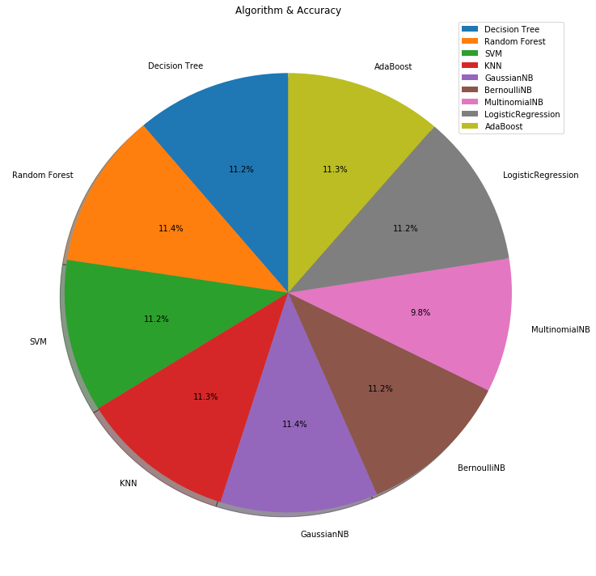

```python
total = sum(result)
area = [(i*360)/total for i in result ]
label = ('Decision Tree','Random Forest','SVM','KNN','GaussianNB','BernoulliNB','MultinomialNB','LogisticRegression','AdaBoost')
plt.figure(figsize=(10,10))
plt.title('Algorithm & Accuracy')
plt.pie(area,labels=label,shadow=True, startangle=90,autopct='%1.1f%%')
plt.legend(label, loc="best")
plt.tight_layout()
```

```python
from statistics import mean
print ("Mean Accuracy %.2f"%(mean(result)*100))
```

```
Mean Accuracy 92.88
```

```python
import timeit
from xgboost import XGBClassifier
from statistics import mean
start = timeit.default_timer()
clf = XGBClassifier().fit(X_train,Y_train);
prediction = clf.predict(X_test)
result.append(accuracy_score(prediction,Y_test))
print("Accuracy is %.2f"%accuracy_score(prediction,Y_test))
print("Time take "+str(timeit.default_timer()-start))
```

```
Accuracy is 0.95
Time take 0.18326801100010925
```

```python
df = pd.DataFrame(X_,columns=['abs','G1','G2'])
```

```python
df.to_csv('sub.csv',index=False)
```